# Exam 1

## Exam 1

#### Question

   El ángulo $\alpha$ y la medida h se relacionan mediante la razón trigonométrica sen($\alpha$) = $\frac{h}{KP}$, de donde se deduce la distancia entre K y P como KP = $\frac{h}{\text{sen}(\alpha)}$ o KP = h $\times$ csc($\alpha$).

   ¿Cuál es la gráfica que muestra las distancias KP, cada vez que K se mueve sobre el segmento QT?

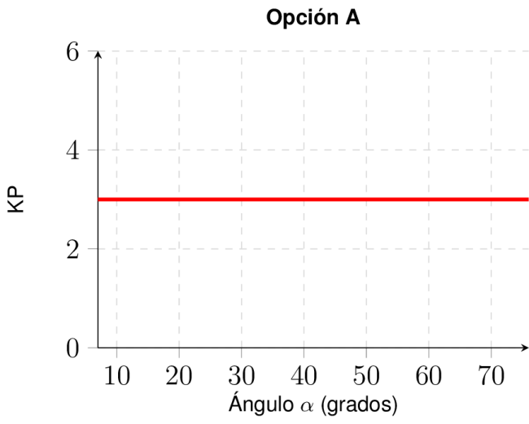

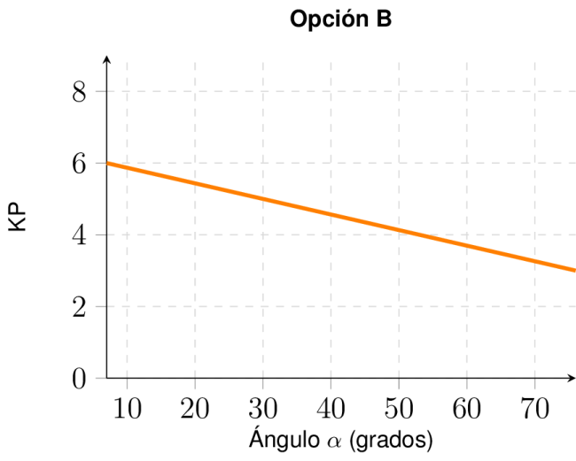

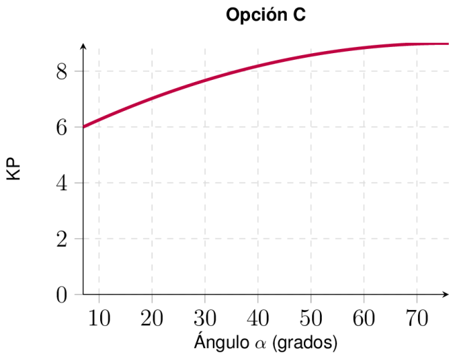

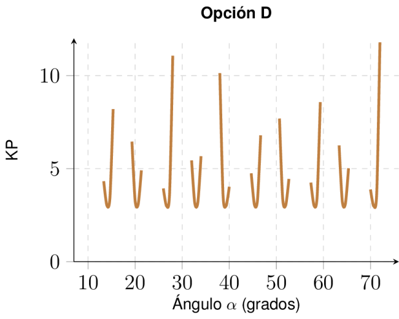

#### Solution

   Para resolver este problema, debemos analizar la función KP = h/sen($\alpha$).

   **Análisis matemático:**

   La función KP = h/sen($\alpha$) = h $\cdot$ csc($\alpha$) es la función cosecante multiplicada por la constante h.

   **Características de la función cosecante:**
   1. **Dominio:** $\alpha \in (0°, 90°)$ en este contexto geométrico
   2. **Comportamiento:**
      - Cuando $\alpha \to 0°$: sen($\alpha$) $\to 0$, por lo tanto KP $\to \infty$
      - Cuando $\alpha \to 90°$: sen($\alpha$) $\to 1$, por lo tanto KP $\to h$
      - La función es estrictamente decreciente en el intervalo (0°, 90°)

   **Verificación con valores específicos:**
   - Para $\alpha$ = 30°: KP = h/sen(30°) = h/0.5 = 2h = 6
   - Para $\alpha$ = 45°: KP = h/sen(45°) = h/($\sqrt{2}$/2) $\approx$ 1.41h $\approx$ 4.2
   - Para $\alpha$ = 60°: KP = h/sen(60°) = h/($\sqrt{3}$/2) $\approx$ 1.15h $\approx$ 3.4

#### Question

   El ángulo $\alpha$ y la medida h se relacionan mediante la razón trigonométrica sen($\alpha$) = $\frac{h}{KP}$, de donde se deduce la distancia entre K y P como KP = $\frac{h}{\text{sen}(\alpha)}$ o KP = h $\times$ csc($\alpha$).

   ¿Cuál es la gráfica que muestra las distancias KP, cada vez que K se mueve sobre el segmento QT?

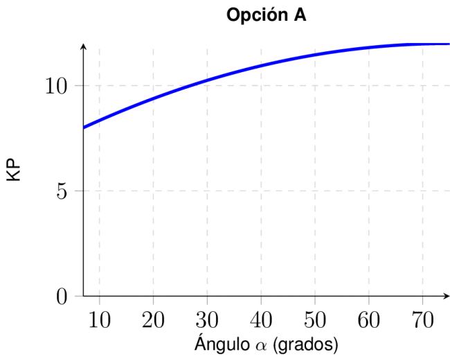

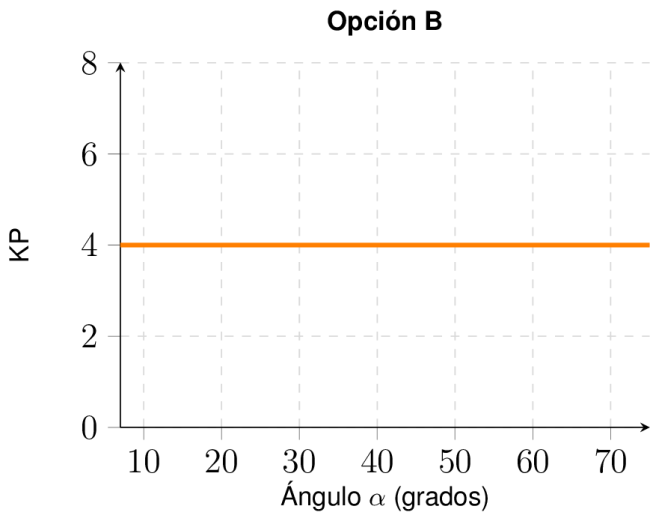

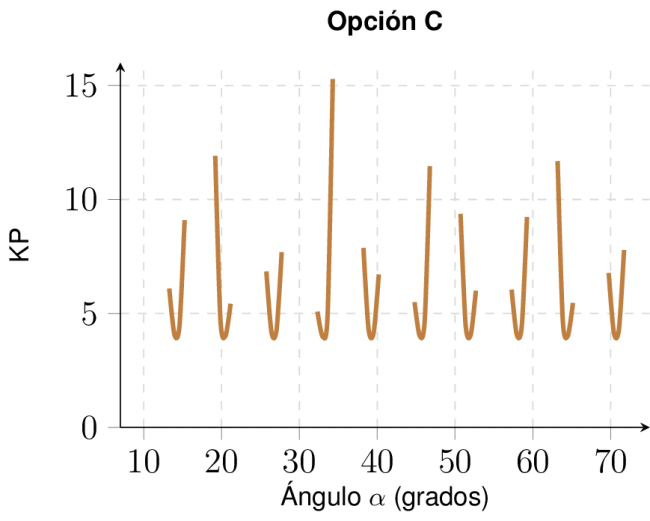

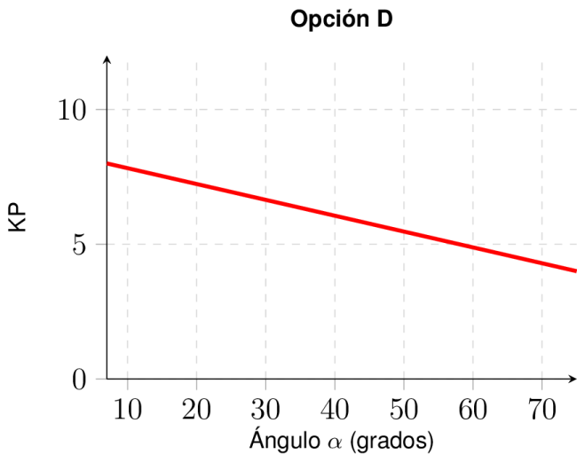

#### Solution

   Para resolver este problema, debemos analizar la función KP = h/sen($\alpha$).

   **Análisis matemático:**

   La función KP = h/sen($\alpha$) = h $\cdot$ csc($\alpha$) es la función cosecante multiplicada por la constante h.

   **Características de la función cosecante:**
   1. **Dominio:** $\alpha \in (0°, 90°)$ en este contexto geométrico
   2. **Comportamiento:**
      - Cuando $\alpha \to 0°$: sen($\alpha$) $\to 0$, por lo tanto KP $\to \infty$
      - Cuando $\alpha \to 90°$: sen($\alpha$) $\to 1$, por lo tanto KP $\to h$
      - La función es estrictamente decreciente en el intervalo (0°, 90°)

   **Verificación con valores específicos:**
   - Para $\alpha$ = 30°: KP = h/sen(30°) = h/0.5 = 2h = 8
   - Para $\alpha$ = 45°: KP = h/sen(45°) = h/($\sqrt{2}$/2) $\approx$ 1.41h $\approx$ 5.6
   - Para $\alpha$ = 60°: KP = h/sen(60°) = h/($\sqrt{3}$/2) $\approx$ 1.15h $\approx$ 4.6

#### Question

   El ángulo $\alpha$ y la medida h se relacionan mediante la razón trigonométrica sen($\alpha$) = $\frac{h}{KP}$, de donde se deduce la distancia entre K y P como KP = $\frac{h}{\text{sen}(\alpha)}$ o KP = h $\times$ csc($\alpha$).

   ¿Cuál es la gráfica que muestra las distancias KP, cada vez que K se mueve sobre el segmento QT?

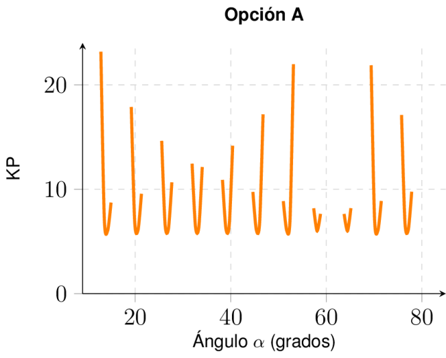

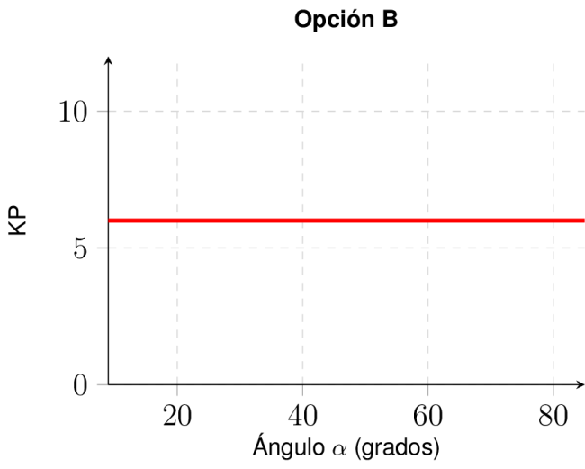

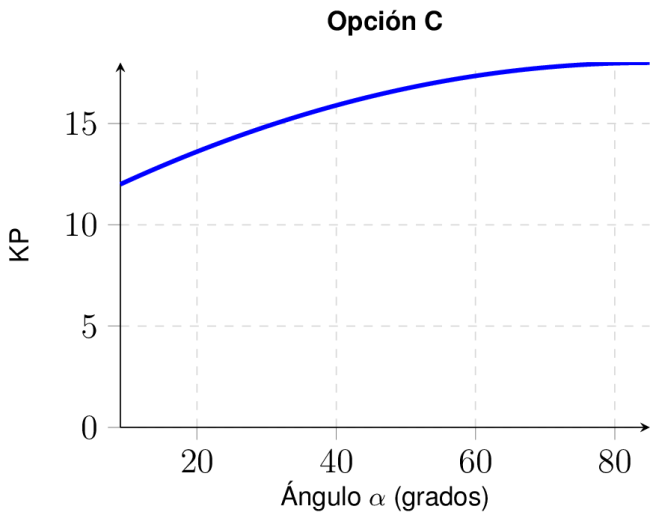

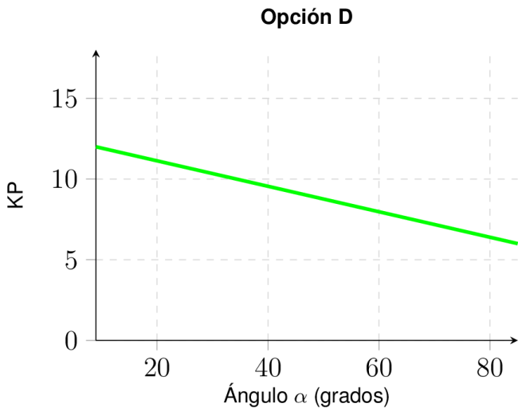

#### Solution

   Para resolver este problema, debemos analizar la función KP = h/sen($\alpha$).

   **Análisis matemático:**

   La función KP = h/sen($\alpha$) = h $\cdot$ csc($\alpha$) es la función cosecante multiplicada por la constante h.

   **Características de la función cosecante:**
   1. **Dominio:** $\alpha \in (0°, 90°)$ en este contexto geométrico
   2. **Comportamiento:**
      - Cuando $\alpha \to 0°$: sen($\alpha$) $\to 0$, por lo tanto KP $\to \infty$
      - Cuando $\alpha \to 90°$: sen($\alpha$) $\to 1$, por lo tanto KP $\to h$
      - La función es estrictamente decreciente en el intervalo (0°, 90°)

   **Verificación con valores específicos:**
   - Para $\alpha$ = 30°: KP = h/sen(30°) = h/0.5 = 2h = 12
   - Para $\alpha$ = 45°: KP = h/sen(45°) = h/($\sqrt{2}$/2) $\approx$ 1.41h $\approx$ 8.5
   - Para $\alpha$ = 60°: KP = h/sen(60°) = h/($\sqrt{3}$/2) $\approx$ 1.15h $\approx$ 6.9